# Actividad 03: Regresión

## Carga de Librerias

```python
import pandas as pd
import matplotlib.pyplot as plt
import seaborn as sb
import numpy as np
```

```python
from google.colab import drive
drive.mount('/content/drive')
```

```python
!ls '/content/drive/Shareddrives/Decisiones Bajo Incertidumbre/03.Actividad Regresion/'
```

```
'03.Descriptivos y SVM.ipynb'   real_estate_valuation_dataset.csv
 modelo_entrenado_SVM.pkl      'XGBoost - Arboles Aleatorios.ipynb'
```

## Lectura de Datos

```python
path = '/content/drive/Shareddrives/Decisiones Bajo Incertidumbre/03.Actividad Regresion'
data = pd.read_csv(path + '/real_estate_valuation_dataset.csv', sep=";",decimal=",",skiprows=1,
    names=['n','fecha_trn', 'antiguedad', 'distancia_trm',
           'nro_tiendas', 'latitud', 'longitud', 'precio'])
print(" Se leyeron los Datos  ")
print( "Número de filas: "+str(data.shape[0]))
print("Número de columnas: "+str(data.shape[1]))
```

```
 Se leyeron los Datos
Número de filas: 414
Número de columnas: 8
```

```python
data.head()
```

|  | n | fecha_trn | antiguedad | distancia_trm | nro_tiendas | latitud | longitud | precio |
| --- | --- | --- | --- | --- | --- | --- | --- | --- |
| 0 | 1 | 2012.917 | 32.0 | 84.87882 | 10 | 24.98298 | 121.54024 | 37.9 |
| 1 | 2 | 2012.917 | 19.5 | 306.59470 | 9 | 24.98034 | 121.53951 | 42.2 |
| 2 | 3 | 2013.583 | 13.3 | 561.98450 | 5 | 24.98746 | 121.54391 | 47.3 |
| 3 | 4 | 2013.500 | 13.3 | 561.98450 | 5 | 24.98746 | 121.54391 | 54.8 |
| 4 | 5 | 2012.833 | 5.0 | 390.56840 | 5 | 24.97937 | 121.54245 | 43.1 |

Cambiar nombre de columnas

```python
#data.columns=['nro','fecha_trn','antiguedad','distancia_trm', 'nro_tiendas','latitud','longitud','precio']
```

## Análisis Descriptivos

### Visualizar Información del Dataset

```python
print(data.info())
```

```
<class 'pandas.core.frame.DataFrame'>
RangeIndex: 414 entries, 0 to 413
Data columns (total 8 columns):
 #   Column         Non-Null Count  Dtype
---  ------         --------------  -----
 0   n              414 non-null    int64
 1   fecha_trn      414 non-null    float64
 2   antiguedad     414 non-null    float64
 3   distancia_trm  414 non-null    float64
 4   nro_tiendas    414 non-null    int64
 5   latitud        414 non-null    float64
 6   longitud       414 non-null    float64
 7   precio         414 non-null    float64
dtypes: float64(6), int64(2)
memory usage: 26.0 KB
None
```

```python
print("Cantidad de datos faltantes por variable")
data.isnull().sum()
```

```
Cantidad de datos faltantes por variable
```

```
n                0
fecha_trn        0
antiguedad       0
distancia_trm    0
nro_tiendas      0
latitud          0
longitud         0
precio           0
dtype: int64
```

### Resumenes Descriptivos

```python
data.describe(include='all')
```

|  | n | fecha_trn | antiguedad | distancia_trm | nro_tiendas | latitud | longitud | precio |
| --- | --- | --- | --- | --- | --- | --- | --- | --- |
| count | 414.000000 | 414.000000 | 414.000000 | 414.000000 | 414.000000 | 414.000000 | 414.000000 | 414.000000 |
| mean | 207.500000 | 2013.148971 | 17.712560 | 1083.885689 | 4.094203 | 24.969030 | 121.533361 | 37.980193 |
| std | 119.655756 | 0.281967 | 11.392485 | 1262.109595 | 2.945562 | 0.012410 | 0.015347 | 13.606488 |
| min | 1.000000 | 2012.667000 | 0.000000 | 23.382840 | 0.000000 | 24.932070 | 121.473530 | 7.600000 |
| 25% | 104.250000 | 2012.917000 | 9.025000 | 289.324800 | 1.000000 | 24.963000 | 121.528085 | 27.700000 |
| 50% | 207.500000 | 2013.167000 | 16.100000 | 492.231300 | 4.000000 | 24.971100 | 121.538630 | 38.450000 |
| 75% | 310.750000 | 2013.417000 | 28.150000 | 1454.279000 | 6.000000 | 24.977455 | 121.543305 | 46.600000 |
| max | 414.000000 | 2013.583000 | 43.800000 | 6488.021000 | 10.000000 | 25.014590 | 121.566270 | 117.500000 |

### Gráfico Boxplot

```python
data.columns
```

```
Index(['n', 'fecha_trn', 'antiguedad', 'distancia_trm', 'nro_tiendas',
       'latitud', 'longitud', 'precio'],
      dtype='object')
```

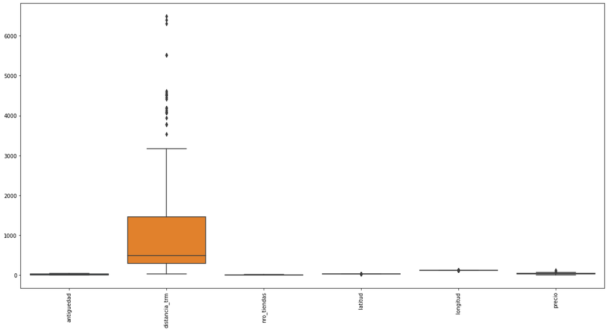

```python
plt.figure(figsize=(20,10))
sb.boxplot(data=pd.DataFrame(data[['antiguedad', 'distancia_trm', 'nro_tiendas',
       'latitud', 'longitud', 'precio']], columns = ['antiguedad', 'distancia_trm', 'nro_tiendas',
       'latitud', 'longitud', 'precio']))
plt.xticks(rotation=90);
```

En los Boxplots se observa que la variable X3:distancia al MRT tiene valores mucho más altos en relación a las demás variables y podriamos considerar escalar los datos, además para esta varible también contiene valores altamente extremos lo que indica que hay viviendas que se encuentran altamente retiradas de un transporte publico masivo.

### Gráfico Pairplot

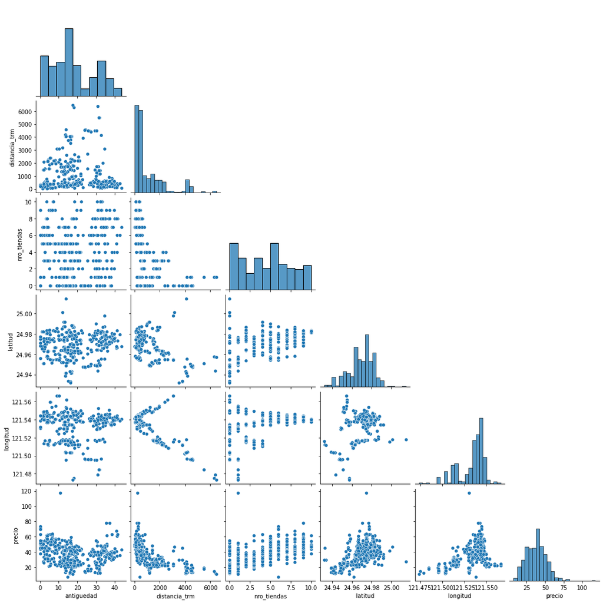

```python
sb.pairplot(data[['antiguedad', 'distancia_trm', 'nro_tiendas',
       'latitud', 'longitud', 'precio']], corner=True ,diag_kind="hist",palette="bright")
```

En el gráfico se observa histogramas para cada una de las variables y sus gráficos de dispersión combinados, esto con el fin de analizar si existen algun patrón en las variables y observar también la distribucción de cada una de ellas, de forma relevante se observa entonces que los precios de las viviendas ciertamente muestran un patrón para algunas varibles como X3 ya que parece influir de manera negativa el que la distancia del transporte MRT este más lejos ,además de la longitud y la latitud de la casa también parecen influir de manera positiva en el precio de la vivienda al igual que X4 que es el número de tiendas más cercanas en el vecindario.

### Gráfico de Correlación

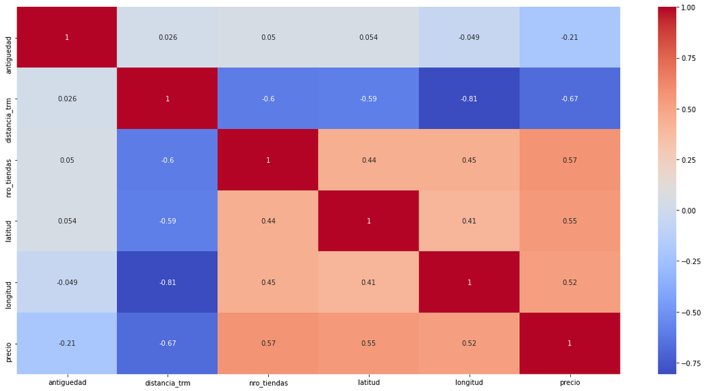

```python
plt.figure(figsize=(20,10))
sb.heatmap(data[['antiguedad', 'distancia_trm', 'nro_tiendas',
       'latitud', 'longitud', 'precio']].corr(),cmap='coolwarm',annot=True)
```

Observando el gráfico de correlación afirmamos el analisis anterior, asi por ejemplo se observa que en Taiwan la variable antiguedad de la casa en años, no parece influir mucho en los precios de la vivienda, por otro lado las demás varibles análizadas indican ya sea correlación positiva y Negativa a excepción de antiguedad.

## Predición del Precio de la vivienda

```python
import warnings
warnings.filterwarnings("ignore")
```

```python
from sklearn.model_selection import train_test_split
from sklearn.preprocessing import MinMaxScaler
from sklearn.preprocessing import StandardScaler
from sklearn.metrics import classification_report, confusion_matrix
from sklearn.preprocessing import LabelEncoder
from sklearn import metrics
from sklearn.compose import ColumnTransformer
from sklearn import preprocessing
from sklearn.pipeline import FeatureUnion
from sklearn.svm import SVR
from sklearn.metrics import r2_score,mean_squared_error,mean_absolute_error
from sklearn.model_selection import GridSearchCV
from sklearn.externals import joblib
```

### Transformación de Datos

Función de Transformación

```python
def transformacion_data(data,transformar):

  if len(data.select_dtypes(include=['object', 'category']).columns.to_list()) != 0:
    l1 = data.select_dtypes(include=['float64', 'int']).columns.to_list()
    l2 = data.select_dtypes(include=['object', 'category']).columns.to_list()
    df1 = data[l1]
    df2 = data[l2]

    for i in df2.columns.tolist():
      le = preprocessing.LabelEncoder()
      le.fit(df2[i])
      df2[i]=le.transform(df2[i])

    if transformar == 'StandardScaler':
      data_conct = pd.concat([df1,df2],axis=1)
      scaler = preprocessing.StandardScaler().fit(data_conct)
      data_transformada = pd.DataFrame(scaler.transform(data_conct),columns=data_conct.columns)
      #data_conct = pd.concat([data_transformada,df2],axis=1)

    elif transformar == 'MinMaxScaler':
      min_max_scaler = preprocessing.MinMaxScaler()
      data_conct = pd.concat([df1,df2],axis=1)
      data_transformada = pd.DataFrame(min_max_scaler.fit_transform(data_conct),columns=data_conct.columns)
      #data_conct = pd.concat([data_transformada,df2],axis=1)


    else:
      data_transformada = pd.concat([df1,df2],axis=1)

    return(data_transformada)

  else:

    if transformar == 'StandardScaler':
      scaler = preprocessing.StandardScaler().fit(data)
      data_transformada = pd.DataFrame(scaler.transform(data),columns=data.columns)
      #data_conct = data_transformada

    elif transformar == 'MinMaxScaler':
      min_max_scaler = preprocessing.MinMaxScaler()
      data_transformada = pd.DataFrame(min_max_scaler.fit_transform(data),columns=data.columns)
      #data_conct = data_transformada

    else:
      data_transformada = data


    return(data_transformada)
```

```python
prueba = pd.DataFrame(np.array([[ 1., -1.,  2.,'A'],
                    [ 2.,  0.,  0.,'B'],
                    [ 0.,  1., -1.,'C']]),columns= ['A','B','C','RESP'])
prueba['A']=prueba['A'].astype(float)
prueba['B']=prueba['B'].astype(float)
prueba['C']=prueba['C'].astype(float)
```

```python
transformacion_data(prueba,'MinMaxScaler')
```

|  | A | B | C | RESP |
| --- | --- | --- | --- | --- |
| 0 | 0.5 | 0.0 | 1.000000 | 0.0 |
| 1 | 1.0 | 0.5 | 0.333333 | 0.5 |
| 2 | 0.0 | 1.0 | 0.000000 | 1.0 |

```python
data_transformada = transformacion_data(data,'StandardScaler')
```

```python
y = data.iloc[:,7]
X = data_transformada.iloc[:, 2:7]

X_train, X_test, y_train, y_test = train_test_split(X, y, test_size=0.20, random_state=0)
```

### Maquinas de Soporte Vectorial

#### Seleccionando el modelo con GridSearchCV

```python
# defining parameter range
param_grid = {'C': [0.1, 1, 10, 100, 1000],
              #'gamma': [1, 0.1, 0.01, 0.001, 0.0001],
              'coef0' : [0.0,0.3,0.5],
              'degree': [1,2,3,4],
              'kernel': ['poly', 'rbf', 'sigmoid']}

#grid = GridSearchCV(SVR(), param_grid, refit = True, verbose = 0)

# fitting the model for grid search
#grid.fit(X_train, y_train)
```

#### Guardar y Cargar Modelo

```python
#joblib.dump(grid, path +'/modelo_entrenado_SVM.pkl') # Guardo el modelo.
```

[output not shown]

```python
SVM_Modelo = joblib.load(path +'/modelo_entrenado_SVM.pkl') # Carga del modelo.
```

```python
print('Mejores Párametros para el modelo:')
print(SVM_Modelo.best_params_)
```

```
Mejores Párametros para el modelo:
{'C': 100, 'coef0': 0.0, 'degree': 1, 'kernel': 'rbf'}
```

```python
print('Modelo:')
print(SVM_Modelo.best_estimator_)
```

```
Modelo:
SVR(C=100, cache_size=200, coef0=0.0, degree=1, epsilon=0.1, gamma='scale',
    kernel='rbf', max_iter=-1, shrinking=True, tol=0.001, verbose=False)
```

Ajuste del modelo con los sus estimadores

```python
#SVM_Reg_Model_Best = grid.best_estimator_
#SVM_Reg_Model_Best.fit(X_train,y_train)
```

```python
print('R2-train: ', SVM_Modelo.score(X_train, y_train))
print('R2-test: ', SVM_Modelo.score(X_test, y_test))
```

```
R2-train:  0.7241537063624657
R2-test:  0.7115303654524674
```

Prediciones para el conjunto de testeo

```python
y_pred_test = SVM_Modelo.predict(X_test)
```

Prediciones para el conjunto de Entrenamiento

```python
y_pred_train = SVM_Modelo.predict(X_train)
```

Coleccion de medidas de Ajuste

```python
mse_test = mean_squared_error(y_test,y_pred_test)
rmse_test = np.sqrt(mse_test)
mae_test = mean_absolute_error(y_test,y_pred_test)
mape_test = np.mean(np.abs((y_test - y_pred_test)/y_test))*100
R2_test = SVM_Modelo.score(X_test, y_test)
```

```python
mse_train = mean_squared_error(y_train,y_pred_train)
rmse_train = np.sqrt(mse_train)
mae_train = mean_absolute_error(y_train,y_pred_train)
mape_train = np.mean(np.abs((y_train - y_pred_train)/y_train))*100
R2_train = SVM_Modelo.score(X_train, y_train)
```

```python
results=pd.DataFrame(data = {'test': [mse_test, rmse_test, mae_test, mape_test,R2_test],'train': [mse_train, rmse_train, mae_train, mape_train,R2_train]},index=['mse', 'rmse', 'mae', 'mape','R2'] ,columns=['test','train'])
```

```python
results
```

|  | test | train |
| --- | --- | --- |
| mse | 50.106891 | 51.706043 |
| rmse | 7.078622 | 7.190691 |
| mae | 5.119844 | 3.702419 |
| mape | 14.741276 | 10.415480 |
| R2 | 0.711530 | 0.724154 |

## Creación de Red Neuronal para predecir el precio de la vivienda en Taiwan

```python
# Importamos las librerias necesarias
import pandas as pd
from keras.models import Sequential
from keras.layers import Dense
from keras.wrappers.scikit_learn import KerasRegressor
from sklearn.model_selection import cross_val_score
from sklearn.model_selection import KFold
from sklearn.preprocessing import StandardScaler
from sklearn.pipeline import Pipeline
from sklearn.model_selection import train_test_split
```

Verifiquemos que la base de datos se ha leido correctamente

```python
data.head()
```

|  | n | fecha_trn | antiguedad | distancia_trm | nro_tiendas | latitud | longitud | precio |
| --- | --- | --- | --- | --- | --- | --- | --- | --- |
| 0 | 1 | 2012.917 | 32.0 | 84.87882 | 10 | 24.98298 | 121.54024 | 37.9 |
| 1 | 2 | 2012.917 | 19.5 | 306.59470 | 9 | 24.98034 | 121.53951 | 42.2 |
| 2 | 3 | 2013.583 | 13.3 | 561.98450 | 5 | 24.98746 | 121.54391 | 47.3 |
| 3 | 4 | 2013.500 | 13.3 | 561.98450 | 5 | 24.98746 | 121.54391 | 54.8 |
| 4 | 5 | 2012.833 | 5.0 | 390.56840 | 5 | 24.97937 | 121.54245 | 43.1 |

Separamos las variables explicativas y la vriable respuesta en dos bases. Las variables explicativas son:

- fecha_trn
- antiguedad
- distancia_trm
- nro_tiendas
- latitud
- longitud

```python
X=data[['fecha_trn', 'antiguedad', 'distancia_trm','nro_tiendas', 'latitud', 'longitud']]
X.head()
```

|  | fecha_trn | antiguedad | distancia_trm | nro_tiendas | latitud | longitud |
| --- | --- | --- | --- | --- | --- | --- |
| 0 | 2012.917 | 32.0 | 84.87882 | 10 | 24.98298 | 121.54024 |
| 1 | 2012.917 | 19.5 | 306.59470 | 9 | 24.98034 | 121.53951 |
| 2 | 2013.583 | 13.3 | 561.98450 | 5 | 24.98746 | 121.54391 |
| 3 | 2013.500 | 13.3 | 561.98450 | 5 | 24.98746 | 121.54391 |
| 4 | 2012.833 | 5.0 | 390.56840 | 5 | 24.97937 | 121.54245 |

```python
Y=data[['precio']]
Y.head()
```

|  | precio |
| --- | --- |
| 0 | 37.9 |
| 1 | 42.2 |
| 2 | 47.3 |
| 3 | 54.8 |
| 4 | 43.1 |

Como tenemos pocos datos (414 registros) vamos a sacar unicamente el 10% de ellos para validar que el modelo no haya quedado sobre entrenado.

```python
X_train, X_test, y_train, y_test = train_test_split(X, Y, test_size = 0.1, random_state = 999)
print(str(X_train.shape[0])+ " registros para entrenar")
print(str(X_test.shape[0]) + " registros para test")
```

```
372 registros para entrenar
42 registros para test
```

Para crear una red neuronal es necesario la definición de un número significativamente alto de parametros, como pr ejemplo, el número de capas, el número de neuronal, la tasa de aprendizaje, la función de activación de cada capa, el metodo de optimización, etc. Encontrar la combinación optima de estos hiperparámetros puede tomar muchisimo tiempo, Existen personas que llevan años entrenando una red neuronal, pero por metodos practicos vamos a definir una red sencilla que ilustre a grandes razgos como sería la metodología para encontrar el modelo optimo.

Por lo general una buena practiva para identificar el número de capas ocultas de la red es:

$$ \begin{aligned} Nh=\frac{Ns}{\alpha*(Ni+No)} \end{aligned} $$

Donde:

- $Ni =$ Número de Neuronas de entrada ( Número de variables )
- $No =$ Número de Neuronas de salida
- $Ns =$ Número de muestras en el conjunto de datos de entrenamiento
- $\alpha =$ Un Factor de escala arbitrario generalmente 2-10

[figure not shown]

```python
# Initialising the ANN
model = Sequential()

# Adding the input layer and the first hidden layer
model.add(Dense(32, activation = 'relu', input_dim = 6))

# Adding the second hidden layer
model.add(Dense(units = 32, activation = 'relu'))
# Adding the third hidden layer
model.add(Dense(units = 32, activation = 'relu'))
# Adding the third hidden layer
model.add(Dense(units = 32, activation = 'relu'))
# Adding the fourth hidden layer
#model.add(Dense(units = 32, activation = 'relu'))

# Adding the output layer
model.add(Dense(units = 1))
model.compile(optimizer = 'adam',loss = 'mean_squared_error')
```

Luego de definir el modelo en la celda anterior procedemos a entrenarlo con los datos tal cual como estan en la base

```python
model.fit(X_train, y_train, batch_size = 5, epochs = 100,validation_data=(X_test,y_test))
```

```
<keras.callbacks.History at 0x7f169009f650>
```

```python
#Estandamizamos las variables de entrada a la red para verificar si mejora el error
from sklearn.preprocessing import StandardScaler
scaler=StandardScaler()
scaler.fit(X_train)
X_train_std=X_train.copy()
X_train_std[['fecha_trn', 'antiguedad', 'distancia_trm','nro_tiendas', 'latitud', 'longitud']]=scaler.transform(X_train)

X_test_std=X_test.copy()
X_test_std[['fecha_trn', 'antiguedad', 'distancia_trm','nro_tiendas', 'latitud', 'longitud']]=scaler.transform(X_test)
```

```python
X_train_std.head()
```

|  | fecha_trn | antiguedad | distancia_trm | nro_tiendas | latitud | longitud |
| --- | --- | --- | --- | --- | --- | --- |
| 245 | 0.956363 | -0.916059 | -0.354899 | 0.301241 | 0.279399 | 0.950445 |
| 196 | -0.530397 | 0.443660 | -0.300958 | -0.739578 | 0.960832 | 0.885054 |
| 312 | 1.548215 | 1.563427 | -0.608534 | 1.688999 | 0.128059 | 0.468107 |
| 135 | -0.826323 | 0.097065 | -0.062933 | -1.433457 | -0.449783 | 1.039144 |
| 398 | 0.956363 | -0.276191 | 0.496296 | -0.739578 | -0.376946 | -1.098683 |

```python
model.fit(X_train_std, y_train, batch_size = 1, epochs = 50,validation_data=(X_test_std,y_test))
```

```
<keras.callbacks.History at 0x7f163af2ac50>
```

Vamos a realizar la predicción sobre toda la base y observamos que tan acertada fue.

```python
data['prediccion_precion_NN']= model.predict(scaler.transform(X))
```

```python
data.head(10)
```

[output not shown]

Se ve relativamente bien para ser las primera iteracciones. Pero calculemos algunos indicadores de desempeños que nos corroboren esto.

```python
y_pred_test = model.predict(scaler.transform(X_test))
y_pred_train = model.predict(scaler.transform(X_train))
```

```python
from sklearn.metrics import r2_score,mean_squared_error,mean_absolute_error
```

```python
mse_test = mean_squared_error(y_test,y_pred_test)
rmse_test = np.sqrt(mse_test)
mae_test = mean_absolute_error(y_test,y_pred_test)
mape_test = np.mean(np.abs((y_test - y_pred_test)/y_test))*100


mse_train = mean_squared_error(y_train,y_pred_train)
rmse_train = np.sqrt(mse_train)
mae_train = mean_absolute_error(y_train,y_pred_train)
mape_train = np.mean(np.abs((y_train - y_pred_train)/y_train))*100
```

```python
results=pd.DataFrame(data = {'test': [mse_test, rmse_test, mae_test, mape_test],'train': [mse_train, rmse_train, mae_train, mape_train]},index=['mse', 'rmse', 'mae', 'mape'] ,columns=['test','train'])
results
```

|  | test | train |
| --- | --- | --- |
| mse | 42.9311 | 45.1687 |
| rmse | 6.55219 | 6.72077 |
| mae | 5.48119 | 4.30355 |
| mape | precio 16.388226 dtype: float64 | precio 11.880896 dtype: float64 |

Un Mape de 16% para test y de 11.8% para entrenamiento me indican que el modelo efectivamente tiene un buen desempeño